# R Notebook

```r
library(readr)
library(dplyr)
library(cluster)
library(fpc)
library(reshape2)
library(ggplot2)
```

LENDO DADOS

```r
filmes <- read_csv("C:/Users/LucasZan/Desktop/Alura/1527-cluster_r-data/movies.csv")
```

```r
df <- read_delim("C:/Users/LucasZan/Desktop/Alura/1527-cluster_r-data/movies_transf.csv",
    ";", escape_double = FALSE, trim_ws = TRUE)
```

```r
filmes_tranformados <- df %>%
                          select(-movieId,-titulo)

#Retirando valores ñ numericos do data frame (titulo e indice(nao importa agr))
```

Normalizando os dados para poder utilizar o machine learning

```r
dados_normalizados <- data.frame( scale(filmes_tranformados) )

#scale faz a normalização dos dados numericos do dataframe, mas o resultado é em matriz, então utiliza-se a função data.frame() pra transfomar de volta em dataframe
```

Utilizando kmeans para gerar os clusters

```r
#para gerar os mesmo resultados da ALura
set.seed(1987)
#como o kmeans escolhe os cluester de forma aleatória usar o seed prar ter o mesmo resultado

resultado_cluster <- kmeans(dados_normalizados, centers = 3)
```

```r
resultado_cluster$cluster
```

[output not shown]

```r
View(resultado_cluster$centers)
```

Analise dos clusters

```r
resultado_cluster$withinss
```

```
[1] 118121.788   3347.528  31281.224
```

O cluster 1 não foi muito bom por causa do resultado muito alto

```r
resultado_cluster$size
```

```
[1] 6797  158 1637
```

O tamanho não está semelhante ou seja é necessario retreinar o modelo com numero diferente de clustes

Plotando os dados do cluster usando a biblioteca cluster

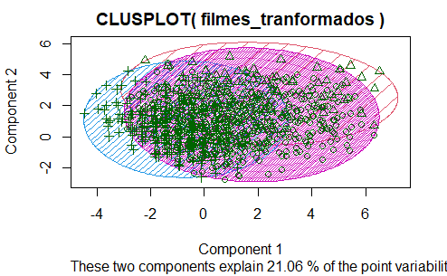

```r
clusplot(x= filmes_tranformados, resultado_cluster$cluster, color = T, shade = T)
```

Pelo gráfico é possivel ver q os clusters estão muito agrupados, tendo dados q estão sobrepostos pelos 3 clustes e a diferença da quantidade de dados em um cluster pela distancia entre linhas

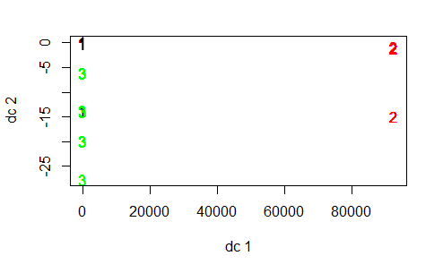

```r
plotcluster(x= filmes_tranformados, resultado_cluster$cluster, ignorenum = T)
```

Para gerar graficos mais faceis de entender para os clientes

```r
centros <- resultado_cluster$centers
centros_2 <- melt(centros)
#renomiando as colunas
colnames(centros_2) <- c('cluster', 'genero', 'centro')
centros_2$cluster <- as.factor(centros_2$cluster) #transforma o valor em fator
```

a função melt vai converter, tranpor a matriz, para gerar um grafico melhor, pois vai colocar em ordem o tipo de filme, e o valor normalizado de seu respectivo cluster

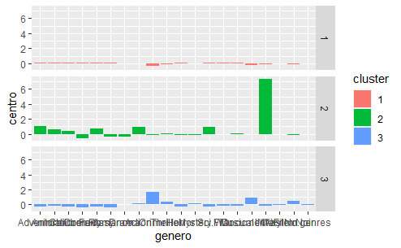

```r
ggplot(data = centros_2) +
  geom_bar(aes(x= genero, y= centro, fill = cluster), stat = 'identity') +
  facet_grid(cluster ~ .)
```

TECNICA ELBOW PARA IDENTIFICAR A MELHOR QUANTIDADE DE CLUSTERS PARA O DATAFRAME UTILIZADO

```r
range_k <- c(1:25)
range_k
```

```
 [1]  1  2  3  4  5  6  7  8  9 10 11 12 13 14 15 16 17 18 19 20 21 22 23 24 25
```

```r
soma_dos_quadrados <- 0
```

```r
set.seed(1987)
for (i in range_k) {
  cluster3 <- kmeans(dados_normalizados, centers = i, nstart = 25)
  soma_dos_quadrados[i] <- sum(cluster3$withinss)
}
```

```r
soma_dos_quadrados
```

```
 [1] 171820.00 158387.74 146332.37 136832.98 129275.09 120686.28 112607.16 105844.64  99562.40  92134.10  84185.59  85052.32
[13]  81602.58  79776.71  71869.73  68704.25  64176.06  65876.48  60238.81  60243.66  55671.31  56386.61  49633.43  54717.98
[25]  54698.77
```

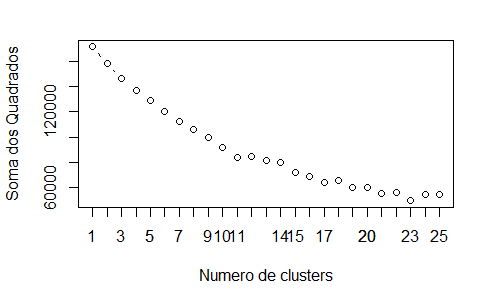

```r
plot(range_k, soma_dos_quadrados, type = 'b',
     xlab = 'Numero de clusters',
     ylab = 'Soma dos Quadrados')
axis(side = 1, at = range_k, labels = range_k)
```

pelo grafico a primeira quebra de linha é no 5 ou sejaseria a melhor quantidade de clusters a se usar

Metodo Silhouette

```r
range_k <- c(2:15)

medias_silhouete <- c(0)
set.seed(1987)
for (i in range_k) {
  cluster3s <- kmeans(dados_normalizados, centers = i)
  silhouete <- silhouette(cluster3s$cluster, dist(dados_normalizados))
  medias_silhouete[i] <- mean( silhouete[,3])
}
```

```r
medias_silhouete

plot(medias_silhouete, type = 'b',
     xlab = 'Numero de clusters',
     ylab = 'Media silhouette')
axis(side = 1, at = range_k, labels = range_k)
```

[output not shown]

Criando o cluster novamente agr com 12 clusters

```r
set.seed(1987)
resultado_cluster <- kmeans(dados_normalizados, centers = 12)
```

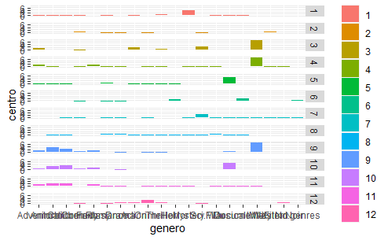

```r
centros <- resultado_cluster$centers
centros_2 <- melt(centros)
colnames(centros_2) <- c('cluster', 'genero', 'centro')
centros_2$cluster <- as.factor(centros_2$cluster)


ggplot(data = centros_2) +
  geom_bar(aes(x= genero, y= centro, fill = cluster), stat = 'identity') +
  facet_grid(cluster ~ .)
```

agr, atribuir a os clusters na nossa base de dados filmes antes de poder indicar algum filme

```r
## Atribuindo cluster para cada filme
filmes$cluster <- resultado_cluster$cluster
View(filmes)
```

Pesquisando a q cluster algum filme pertence

```r
## fazendo recomendação a partir de um filme
agrupamento <- filmes[filmes$title == 'Toy Story (1995)','cluster']
agrupamento
```

| cluster |
| --- |
| 11 |

Sabendo em que cluster toy story ta, podemos buscar por filmes nesse cluster

```r
## selecinando 10 filmes dentro do cluster
filmes[filmes$cluster == agrupamento, 'title'] %>%
  sample(10)
```

```
Error in sample.int(length(x), size, replace, prob) :
  impossível tomar uma amostra maior que a população quando 'replace = FALSE'
```

Clusters Hierarquicos

```r
matriz_dist <- dist(centros) #method = "euclidean"  # matrix de distÃ¢ncia
matriz_dist
```

```
           1         2         3         4         5
2   4.702909
3   8.977094  8.217195
4   8.907087  8.012480  3.600983
5   6.857326  5.385280  9.793712  9.328189
6   4.857228  2.986104  8.564267  8.118847  5.890054
7   5.227642  3.681812  7.628621  8.419940  6.377323
8   4.668497  2.272573  8.392176  8.082247  5.307025
9  10.180865  9.104290  5.892683  4.921729 10.228533
10  8.168479  6.785170 10.639218  9.898245  4.571799
11  5.950950  3.921114  8.749150  8.098592  6.675480
12  4.567654  3.315674  8.389106  8.442939  6.079065
           6         7         8         9        10
2
3
4
5
6
7   4.137417
8   3.416877  4.006488
9   9.639262  9.452810  9.382702
10  7.403078  7.525399  7.043897  8.786898
11  4.932129  4.706046  4.406859  7.735796  5.470473
12  4.008599  4.431105  3.349519  9.771362  7.618042
          11
2
3
4
5
6
7
8
9
10
11
12  5.113084
```

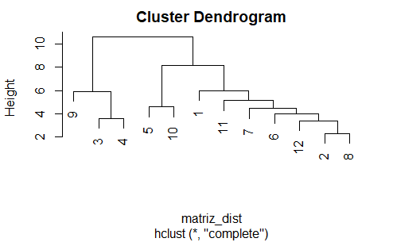

```r
## criando objeto de cluster hierarquico
clust_h <- hclust(matriz_dist) #, method = "complete")

## grafico com o cluster hierarquico
plot(clust_h)
```

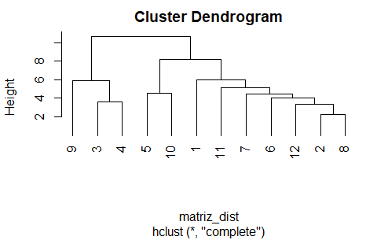

```r
plot(clust_h,hang = -1)
```